# Nigerian Graduates Analysis

Damola Mabogunje

2022-06-19

## Introduction

This R Markdown document is created to explore the Nigerian Graduate Destination Survey (2013 - 2017) dataset. In it, we will look through the data to answer a few questions like “What is the gender spread of this Survey?”, “Which Institutions are represented?,”What are the most prominent levels of education?“, and so on. From there, we might take on more difficult questions.

But first, we have to prepare the dataset:

```r
survey <- read.csv(here("data/Nigerian Graduates Destination Survey (2013 -2017).csv"));

glimpse(survey);
```

```
## Rows: 5,219
## Columns: 36
## $ Timestamp                                                                                                                    <chr> …
## $ What.is.your.gender                                                                                                          <chr> …
## $ Year.of.graduation                                                                                                           <int> …
## $ Title.of.course.studied                                                                                                      <chr> …
## $ Polytechnic.University.attended                                                                                              <chr> …
## $ What.is.your.highest.level.of.education.                                                                                     <chr> …
## $ What.best.describes.your.current.status.                                                                                     <chr> …
## $ How.many.jobs.have.you.had.since.graduation.including.your.current.one.                                                      <int> …
## $ Have.you.completed.your.NYSC.                                                                                                <chr> …
## $ If.you.answered.yes.ongoing.to.the.previous.question..what.year.did.you..or.will.you..complete.your.NYSC.                    <int> …
## $ Did.you.get.your.first.full.time.job.through.your.NYSC.placement.                                                            <chr> …
## $ Thinking.about.your.first.employment.after.graduation..what.was.your.job.level.                                              <chr> …
## $ What.is.was.your.job.role.                                                                                                   <chr> …
```

[output cut: 23 more lines]

```r
dataset <- survey %>% rename(
  gender = What.is.your.gender,
  graduation = Year.of.graduation,
  course = Title.of.course.studied,
  institution = Polytechnic.University.attended,
  degree = What.is.your.highest.level.of.education.,
  status = What.best.describes.your.current.status.,
  no_of_jobs = How.many.jobs.have.you.had.since.graduation.including.your.current.one.,
  NYSC = Have.you.completed.your.NYSC.,
  NYSC_year = If.you.answered.yes.ongoing.to.the.previous.question..what.year.did.you..or.will.you..complete.your.NYSC.,
  NYSC_job = Did.you.get.your.first.full.time.job.through.your.NYSC.placement.,
  first_job_level = Thinking.about.your.first.employment.after.graduation..what.was.your.job.level.,
  first_job_role = What.is.was.your.job.role.,
  first_job_sector = What.sector.industry.is.your.company.in...E.g..Banking..Agriculture..Telecommunication.,
  first_job_salary = Still.thinking.about.your.first.employment..what.is.was.your.monthly.income.level.,
  first_job_degree_needed = Did.you.need.your.higher.education.qualification.to.get.your.first.job..the.actual.qualification..not.the.subject.of.study..,
  first_job_reason = What.was.the.most.significant.reason.for.deciding.to.take.your.first.job.,
  job_level = Thinking.about.your.current.employment..what.is.your.job.level.,
  job_role = What.is.your.job.role.,
  job_sector = What.sector.industry.is.your.company.in...E.g..Banking..Agriculture..Telecommunication..1,
  job_salary = What.is.your.current.monthly.income.level.,
  job_degree_needed = Did.you.need.your.higher.education.qualification.to.get.this.job..the.actual.qualification..not.the.subject.of.study..,
  job_reason = What.was.the.most.significant.reason.for.deciding.to.take.this.job.,
  best_employer = Which.employer.in.the.country.do.you.think.offers.the.best.opportunities.for.graduates.,
  best_employer_reason = Reason.why.,
  best_sector = Which.sector.is.your.most.preferred.sector.to.work.in.,
  salary_currency = What.currency.are.you.currently.paid.in.,
  work_hours = Approximately.how.many.hours.a.day.do.you.currently.work.,
  employment_reason = As.far.as.you.are.aware..what.was.most.important.to.your.current.employer.about.your.qualification.,
  job_discovery = How.do.you.find.out.about.your.job.s..,
  job_IT = Thinking.about.your.current.employment..did.you.work.for.your.employer.before.or.during.your..higher.education.study.,
  transport = Which.form.of.transport.do.you.use.the.most.,
  first_job_earning_power = Were.you.able.to.rent.an.apartment.or.buy.a.car.from.the.salary.you.got.from.your.first.job.,
  study_to_job = My.course.of.study.prepared.me.well.for.employment,
  study_to_education = My.course.of.study.prepared.me.well.for.further.studies,
  study_benefits = Which.of.these.skills.knowledge.did.your.higher.education.prepare.you.for.
);

glimpse(dataset);
```

```
## Rows: 5,219
## Columns: 36
## $ Timestamp               <chr> "2/8/2018 9:05:23", "2/15/2018 12:11:32", "2/1…
## $ gender                  <chr> "Male", "Male", "Female", "Male", "Female", "M…
## $ graduation              <int> 2013, 2014, 2013, 2017, 2013, 2015, 2013, 2015…
## $ course                  <chr> "Electrical & Electronic Engineering", "Psycho…
## $ institution             <chr> "Obafemi Awolowo University,Ile-Ife", "Obafemi…
## $ degree                  <chr> "Bachelor's degree", "Bachelor's degree", "Bac…
## $ status                  <chr> "Working full time (paid employment)", "Workin…
## $ no_of_jobs              <int> 3, 2, 2, 0, 3, 2, 4, 1, 2, 0, 3, 2, 0, 3, 0, 1…
## $ NYSC                    <chr> "", "Yes", "Yes", "Yes", "Yes", "No", "Yes", "…
## $ NYSC_year               <int> NA, 2017, NA, NA, 2016, 2013, 2016, 2017, 2018…
## $ NYSC_job                <chr> "", "No", "No", "No", "No", "No", "No", "No", …
## $ first_job_level         <chr> "Experience", "Entry level", "Entry level", ""…
## $ first_job_role          <chr> "", "", "Option 1", "", "Operations Manager", …
```

[output cut: 23 more lines]

## What is the Gender Spread?

Now, we can answer a few questions. Like, “What is the gender spread of those surveyed?”

```r
dataset %>% count(gender);
```

```
##              gender    n
## 1            Female 2592
## 2              Male 2624
## 3 Prefer not to say    3
```

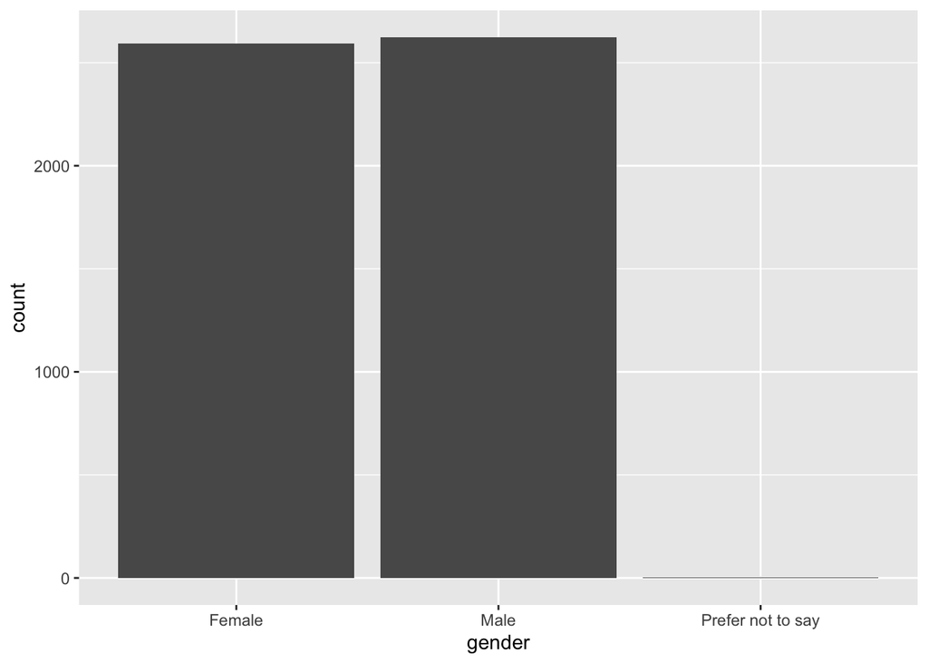

```r
dataset %>% ggplot(aes(gender)) +
  geom_bar();
```

So there are about 32 more men than women who participated in this survey, which is minor considering the over 5000 participants. There are also a negligible 3 participants that did not declare their gender.

## When Did These Graduates Graduate?

Now, over what years did our survey participants graduate?

```r
min(dataset$graduation);
```

```
## [1] 2013
```

```r
max(dataset$graduation);
```

```
## [1] 2017
```

As expected, it spans the period 2013 - 2017.

## Which Institutions Were Survey Participants From?

```r
distinct(dataset['institution']);
```

```
##                                                                                            institution
## 1                                                                   Obafemi Awolowo University,Ile-Ife
## 2                                                                 Bells University of Technology, Otta
## 3                                                                                Bowen University, Iwo
## 4                                                                               Ekiti State University
## 5                                                                                  University of Benin
## 6                                                                              Covenant University Ota
## 7                                                                                  University of Lagos
## 8                                                                                 University of Ibadan
## 9                                                                          University of Port-Harcourt
## 10                                                                     Babcock University,Ilishan-Remo
## 11                                                      Yaba College of Technology, Yaba, Lagos State.
## 12                                                                     University of Abuja, Gwagwalada
## 13                                                             Federal University of Technology, Akure
## 14                                                       Kwara State Polytechnic, Ilorin, Kwara State.
```

[output cut: 144 more lines]

It looks like students were spread across about 158 different institutions.

## How many of the graduates completed NYSC and secured a job from it?

```r
nysc_data <- select(dataset, starts_with("NYSC"));
nysc_data %>% count(NYSC_job);
```

```
##                       NYSC_job    n
## 1                                 1
## 2 I have not completed my NYSC  860
## 3                           No 3561
## 4                          Yes  797
```

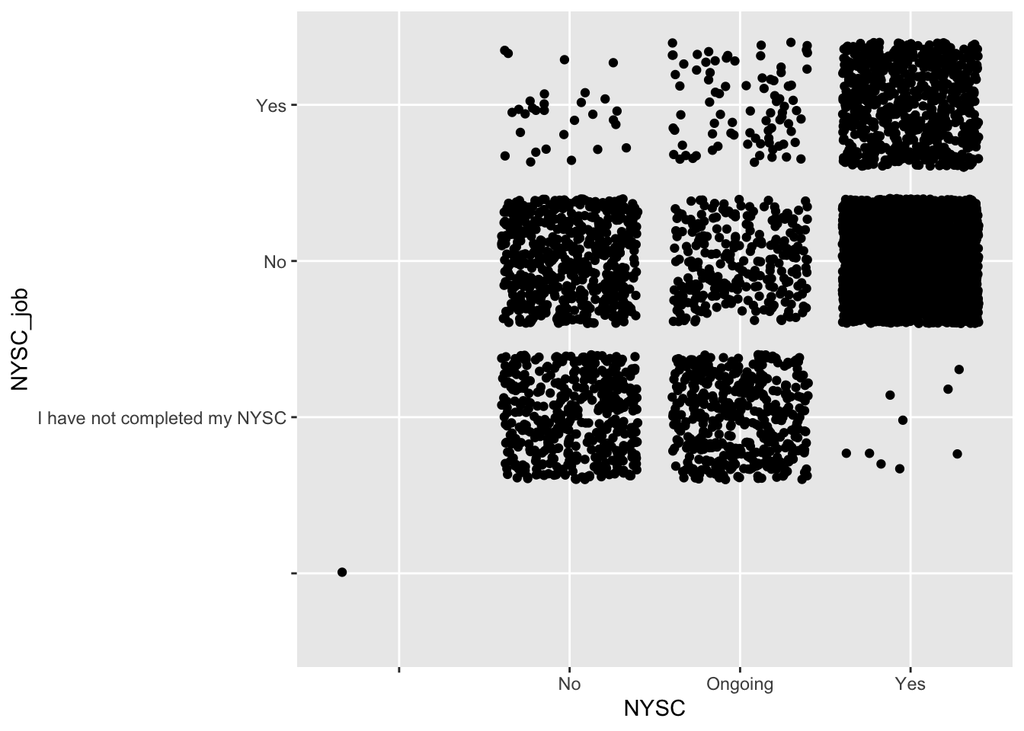

```r
nysc_data %>% ggplot(aes(x=NYSC, y=NYSC_job)) + geom_jitter();
```

So it looks like the data is a bit faulty because we have participants who answered that they haven’t done NYSC while at the same time claiming that they got their first job through NYSC and also participants claiming that they have done NYSC while at the same time saying that they have not yet completed it. This is obvious from the plot.

Similarly, obvious from the job count, is the fact that most graduates did not secure a job through NYSC. And out of the ones that say they did, a good number are still currently in the NYSC program so it is unclear whether they will be kept on post NYSC.